# DataSpace Project : Absenteeism at work

### Gaetano Ferrara s254904

The main purpose of this report is to analyse the dataset "Absenteeism at work Data Set", downloadable from UCI Machine Learning (https://archive.ics.uci.edu/ml/datasets/Absenteeism+at+work). Every record contains many different features that describe personal characteristics of the individual. The objective is to predict if a given employee make no_absenteeism or absenteeism . This is possible thanks to the prediction of an index named "Absenteeism time in hours" that show number of absenteeism.

```python
import pandas as pd
import matplotlib.pyplot as plt
import plotly.graph_objs as go
from plotly.offline import download_plotlyjs, init_notebook_mode, plot, iplot
init_notebook_mode(connected=True)
from sklearn.utils import resample
import numpy as np
import seaborn as sns
from sklearn.linear_model import LinearRegression
import warnings
warnings.filterwarnings("ignore")
```

The dataset is loaded into a pandas Dataframe that offers great flexibility to manipulate data.

```python
input_data = pd.read_excel("C:/Users/fgaet/Desktop/DataSpace_project/Absenteeism_at_work.xls")
pd.options.display.max_columns = None #show all columns

print("instances: %d"%(input_data.shape[0]))
print("features : %d"%(input_data.shape[1]))
```

```
instances: 740
features : 21
```

```python
input_data.head()
```

|  | ID | Reason for absence | Month of absence | Day of the week | Seasons | Transportation expense | Distance from Residence to Work | Service time | Age | Work load Average/day | Hit target | Disciplinary failure | Education | Son | Social drinker | Social smoker | Pet | Weight | Height | Body mass index | Absenteeism time in hours |
| --- | --- | --- | --- | --- | --- | --- | --- | --- | --- | --- | --- | --- | --- | --- | --- | --- | --- | --- | --- | --- | --- |
| 0 | 11 | 26 | 7 | 3 | 1 | 289 | 36 | 13 | 33 | 239554 | 97 | 0 | 1 | 2 | 1 | 0 | 1 | 90 | 172 | 30 | 4 |
| 1 | 36 | 0 | 7 | 3 | 1 | 118 | 13 | 18 | 50 | 239554 | 97 | 1 | 1 | 1 | 1 | 0 | 0 | 98 | 178 | 31 | 0 |
| 2 | 3 | 23 | 7 | 4 | 1 | 179 | 51 | 18 | 38 | 239554 | 97 | 0 | 1 | 0 | 1 | 0 | 0 | 89 | 170 | 31 | 2 |
| 3 | 7 | 7 | 7 | 5 | 1 | 279 | 5 | 14 | 39 | 239554 | 97 | 0 | 1 | 2 | 1 | 1 | 0 | 68 | 168 | 24 | 4 |
| 4 | 11 | 23 | 7 | 5 | 1 | 289 | 36 | 13 | 33 | 239554 | 97 | 0 | 1 | 2 | 1 | 0 | 1 | 90 | 172 | 30 | 2 |

From the official UCI Dataset Repository, we have a deep description of our dataset

1. Abstract: Classify absenteism at work
2. Data Set Characteristics: Multivariate,time-Series
3. Number of Instances: 740
4. Attribute Characteristics: Real,integer
5. Number of Attributes:21
6. Associated Tasks:Classification
7. Missing Values? N/A
8. Number of Web Hits: 129510

Attribute Information:

1. Individual identification (ID)
2. Reason for absence (ICD).
3. Absences attested by the International Code of Diseases (ICD) stratified into 28 categories (1 to 28) as follows:

   ```
    1 Certain infectious and parasitic diseases
    2 Neoplasms
    3 Diseases of the blood and blood-forming organs and certain disorders involving the immune mechanism
    4 Endocrine, nutritional and metabolic diseases
    5 Mental and behavioural disorders
    6 Diseases of the nervous system
    7 Diseases of the eye and adnexa
    8 Diseases of the ear and mastoid process
    9 Diseases of the circulatory system
    10 Diseases of the respiratory system
    11 Diseases of the digestive system
    12 Diseases of the skin and subcutaneous tissue
    13 Diseases of the musculoskeletal system and connective tissue
    14 Diseases of the genitourinary system
    15 Pregnancy, childbirth and the puerperium
    16 Certain conditions originating in the perinatal period
    17 Congenital malformations, deformations and chromosomal abnormalities
    18 Symptoms, signs and abnormal clinical and laboratory findings, not elsewhere classified
    19 Injury, poisoning and certain other consequences of external causes
    20 External causes of morbidity and mortality
    21 Factors influencing health status and contact with health services.
    22 patient follow-up
    23 medical consultation
    24 blood donation
    25 laboratory examination
    26 unjustified absence
    27 physiotherapy
    28 dental consultation
   ```

4. Month of absence
5. Day of the week (Monday (2), Tuesday (3), Wednesday (4), Thursday (5), Friday (6))
6. Seasons (summer (1), autumn (2), winter (3), spring (4))
7. Transportation expense
8. Distance from Residence to Work (kilometers)
9. Service time
10. Age
11. Work load Average/day
12. Hit target
13. Disciplinary failure (yes=1; no=0)
14. Education (high school (1), graduate (2), postgraduate (3), master and doctor (4))
15. Son (number of children)
16. Social drinker (yes=1; no=0)
17. Social smoker (yes=1; no=0)
18. Pet (number of pet)
19. Weight
20. Height
21. Body mass index
22. Absenteeism time in hours (target)

# 1. Data Visualization

Below infos on types of data are displayed

```python
types=pd.DataFrame(input_data.dtypes)
types.columns = ['Types']
types
```

|  | Types |
| --- | --- |
| ID | int64 |
| Reason for absence | int64 |
| Month of absence | int64 |
| Day of the week | int64 |
| Seasons | int64 |
| Transportation expense | int64 |
| Distance from Residence to Work | int64 |
| Service time | int64 |
| Age | int64 |
| Work load Average/day | int64 |
| Hit target | int64 |
| Disciplinary failure | int64 |
| Education | int64 |
| Son | int64 |
| Social drinker | int64 |
| Social smoker | int64 |
| Pet | int64 |
| Weight | int64 |
| Height | int64 |
| Body mass index | int64 |
| Absenteeism time in hours | int64 |

```python
input_data.info()
```

```
<class 'pandas.core.frame.DataFrame'>
RangeIndex: 740 entries, 0 to 739
Data columns (total 21 columns):
ID                                 740 non-null int64
Reason for absence                 740 non-null int64
Month of absence                   740 non-null int64
Day of the week                    740 non-null int64
Seasons                            740 non-null int64
Transportation expense             740 non-null int64
Distance from Residence to Work    740 non-null int64
Service time                       740 non-null int64
Age                                740 non-null int64
Work load Average/day              740 non-null int64
Hit target                         740 non-null int64
Disciplinary failure               740 non-null int64
Education                          740 non-null int64
Son                                740 non-null int64
Social drinker                     740 non-null int64
Social smoker                      740 non-null int64
Pet                                740 non-null int64
Weight                             740 non-null int64
Height                             740 non-null int64
Body mass index                    740 non-null int64
Absenteeism time in hours          740 non-null int64
dtypes: int64(21)
memory usage: 121.5 KB
```

here we can see that all the values are integers and that there are any null values. In fact, it is possible to see that all features have an integer value.

```python
def domain_features(df,features):
    for feature in features:
        print("Number of different value for '",feature,"': " , len(df[feature].unique()))

features = ["ID","Month of absence","Reason for absence","Day of the week","Seasons","Transportation expense","Distance from Residence to Work","Hit target","Disciplinary failure","Education","Son","Social drinker","Social smoker","Pet","Weight","Height","Body mass index","Absenteeism time in hours"]
domain_features(input_data,features)
```

```
Number of different value for ' ID ':  36
Number of different value for ' Month of absence ':  13
Number of different value for ' Reason for absence ':  28
Number of different value for ' Day of the week ':  5
Number of different value for ' Seasons ':  4
Number of different value for ' Transportation expense ':  24
Number of different value for ' Distance from Residence to Work ':  25
Number of different value for ' Hit target ':  13
Number of different value for ' Disciplinary failure ':  2
Number of different value for ' Education ':  4
Number of different value for ' Son ':  5
Number of different value for ' Social drinker ':  2
Number of different value for ' Social smoker ':  2
Number of different value for ' Pet ':  6
Number of different value for ' Weight ':  26
Number of different value for ' Height ':  14
Number of different value for ' Body mass index ':  17
Number of different value for ' Absenteeism time in hours ':  19
```

Here we can see the number of different possible values for each features. Here we can see that for the target feature(Absenteeism time in hours) there are many different value, 19. Then, a èpssible approach could be splitting data into two set based on the previous features: [0,5] low absenteeism and [6>] high absenteeism so that i can apply binary classification.

```python
input_data.describe(include ='all')
```

|  | ID | Reason for absence | Month of absence | Day of the week | Seasons | Transportation expense | Distance from Residence to Work | Service time | Age | Work load Average/day | Hit target | Disciplinary failure | Education | Son | Social drinker | Social smoker | Pet | Weight | Height | Body mass index | Absenteeism time in hours |
| --- | --- | --- | --- | --- | --- | --- | --- | --- | --- | --- | --- | --- | --- | --- | --- | --- | --- | --- | --- | --- | --- |
| count | 740.000000 | 740.000000 | 740.000000 | 740.000000 | 740.000000 | 740.000000 | 740.000000 | 740.000000 | 740.000000 | 740.000000 | 740.000000 | 740.000000 | 740.000000 | 740.000000 | 740.000000 | 740.000000 | 740.000000 | 740.000000 | 740.000000 | 740.000000 | 740.000000 |
| mean | 18.017568 | 19.216216 | 6.324324 | 3.914865 | 2.544595 | 221.329730 | 29.631081 | 12.554054 | 36.450000 | 271490.235135 | 94.587838 | 0.054054 | 1.291892 | 1.018919 | 0.567568 | 0.072973 | 0.745946 | 79.035135 | 172.114865 | 26.677027 | 6.924324 |
| std | 11.021247 | 8.433406 | 3.436287 | 1.421675 | 1.111831 | 66.952223 | 14.836788 | 4.384873 | 6.478772 | 39058.116188 | 3.779313 | 0.226277 | 0.673238 | 1.098489 | 0.495749 | 0.260268 | 1.318258 | 12.883211 | 6.034995 | 4.285452 | 13.330998 |
| min | 1.000000 | 0.000000 | 0.000000 | 2.000000 | 1.000000 | 118.000000 | 5.000000 | 1.000000 | 27.000000 | 205917.000000 | 81.000000 | 0.000000 | 1.000000 | 0.000000 | 0.000000 | 0.000000 | 0.000000 | 56.000000 | 163.000000 | 19.000000 | 0.000000 |
| 25% | 9.000000 | 13.000000 | 3.000000 | 3.000000 | 2.000000 | 179.000000 | 16.000000 | 9.000000 | 31.000000 | 244387.000000 | 93.000000 | 0.000000 | 1.000000 | 0.000000 | 0.000000 | 0.000000 | 0.000000 | 69.000000 | 169.000000 | 24.000000 | 2.000000 |
| 50% | 18.000000 | 23.000000 | 6.000000 | 4.000000 | 3.000000 | 225.000000 | 26.000000 | 13.000000 | 37.000000 | 264249.000000 | 95.000000 | 0.000000 | 1.000000 | 1.000000 | 1.000000 | 0.000000 | 0.000000 | 83.000000 | 170.000000 | 25.000000 | 3.000000 |
| 75% | 28.000000 | 26.000000 | 9.000000 | 5.000000 | 4.000000 | 260.000000 | 50.000000 | 16.000000 | 40.000000 | 294217.000000 | 97.000000 | 0.000000 | 1.000000 | 2.000000 | 1.000000 | 0.000000 | 1.000000 | 89.000000 | 172.000000 | 31.000000 | 8.000000 |
| max | 36.000000 | 28.000000 | 12.000000 | 6.000000 | 4.000000 | 388.000000 | 52.000000 | 29.000000 | 58.000000 | 378884.000000 | 100.000000 | 1.000000 | 4.000000 | 4.000000 | 1.000000 | 1.000000 | 8.000000 | 108.000000 | 196.000000 | 38.000000 | 120.000000 |

Here a legend of what the given stats represent:

```
count: number of samples
mean: the mean of this attribute among all samples
std: the standard deviation of this attribute
min: the minimal value of this attribute
25%: the lower percentage
50%: the median
75%: the upper percentage
max: the maximum value of the attribute
```

We could notice that features are no normalized value selection. That means that before to developed classification tools i need to normalize dataset.

### Bar Chart and Pie Chart of distribution of some categorical feature

#### Pie Chart

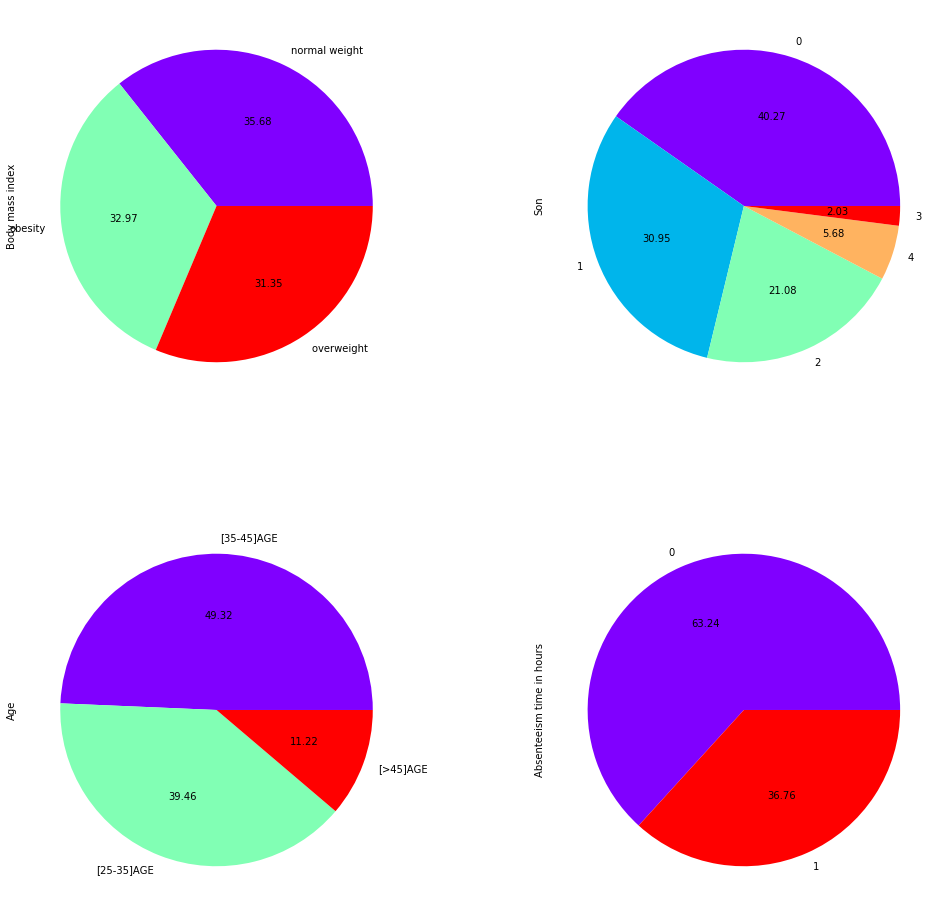

```python
input_data2 = pd.read_excel("C:/Users/fgaet/Desktop/DataSpace_project/Absenteeism_at_work.xls")
son_number = []
age = [];
target_absenteeism = [];
bmi =[]

for index,row in input_data2.iterrows():

    if row['Absenteeism time in hours'] <= 5 :

        target_absenteeism.append(0);
    if row['Absenteeism time in hours'] > 5 :
        target_absenteeism.append(1);




    if row['Son'] == 0 :
           son_number.append(0);
    if row['Son'] == 1 :
           son_number.append(1);
    if row['Son'] > 1  :
           son_number.append(row['Son']);


    if row['Age'] > 24 and row['Age'] < 36 :
           age.append("[25-35]AGE");
    if row['Age'] > 35 and row['Age'] < 46 :
           age.append("[35-45]AGE");
    if row['Age'] > 45 :
           age.append("[>45]AGE");


    if row['Body mass index'] > 18.5 and row['Body mass index'] <= 24.9 :
           bmi.append("normal weight");
    if row['Body mass index'] >= 25 and row['Body mass index'] <= 29.9 :
           bmi.append("overweight ");
    if row['Body mass index'] <= 18.5 :
           bmi.append("underweight");
    if row['Body mass index'] >= 30 :
           bmi.append("obesity");

input_data2['Body mass index'] =  bmi
input_data2['Absenteeism time in hours'] = target_absenteeism;


input_data2['Son'] = son_number;
input_data2['Age'] = age;

plt.subplot(224)
countries = input_data2['Absenteeism time in hours'].value_counts().plot(kind='pie', autopct='%.2f', figsize=(15, 15), cmap="rainbow")
plt.subplot(222)
ethnicities = input_data2['Son'].value_counts().plot(kind='pie', autopct='%.2f', cmap="rainbow")
plt.subplot(223)
ages = input_data2['Age'].value_counts().plot(kind='pie', autopct='%.2f', cmap="rainbow")
plt.subplot(221)
ages = input_data2['Body mass index'].value_counts().plot(kind='pie', autopct='%.2f', cmap="rainbow")
plt.subplots_adjust(top=0.92, bottom=0.08, left=0.10, right=0.95, hspace=0.25,
                    wspace=0.35)
plt.show()
```

Looking at the 4 graphs above, there are some interesting information to note:

1. The ranges of bmi looks like well-distribuited.
2. Fairly, most of the population ranges from 25 to 45 years.
3. More than 50% of the samples have at least one son.

#### Bar Chart

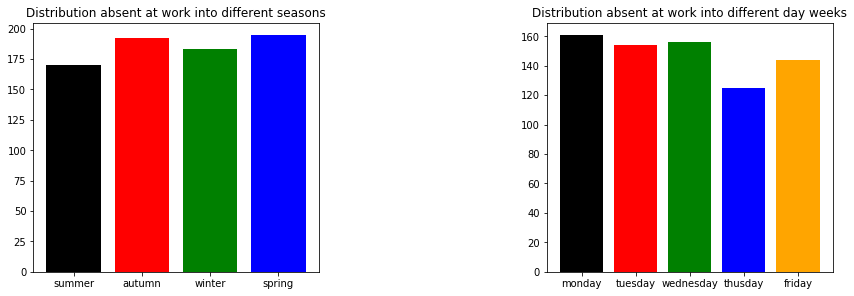

```
people with high absenteeism 272
```

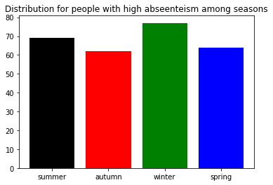

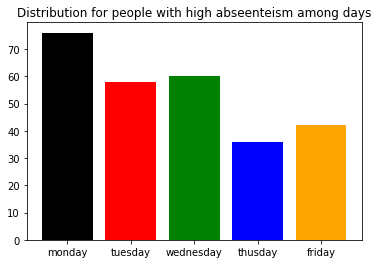

```
someone_to_lookafter : 184
nosomeone_to_lookafter : 88
```

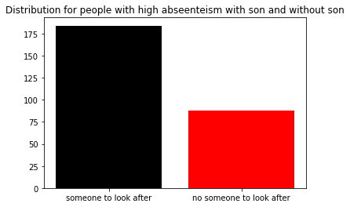

```python
monday_number =0;
tuesday_number =0;
wednesday_number =0;
thusday_number =0;
friday_number = 0;
winter_number2 =0;
summer_number2 =0;
autumn_number2 =0;
spring_number2 =0;
someone_to_lookafter = 0
nosomeone_to_lookafter = 0
someone_to_lookafter1 = 0
nosomeone_to_lookafter1 = 0
days_week=['monday','tuesday','wednesday','thusday','friday'];
analysis_season =['summer','autumn','winter','spring'];
lookafter_array =['someone to look after' , 'no someone to look after']

plt.figure(1)
sum_seasons_absent=[(input_data['Seasons'] == 1).sum(),(input_data['Seasons'] == 2).sum(),(input_data['Seasons'] == 3).sum(),(input_data['Seasons'] == 4).sum()]
plt.subplot2grid((2,2), (0,0))
plt.title("Distribution absent at work into different seasons");
plt.bar(analysis_season ,sum_seasons_absent , color=['black', 'red', 'green', 'blue','orange'])
plt.xticks(analysis_season, analysis_season)


sum_days_absent=[(input_data['Day of the week'] == 2).sum(),(input_data['Day of the week'] == 3).sum(),(input_data['Day of the week'] == 4).sum(),(input_data['Day of the week'] == 5).sum(),(input_data['Day of the week'] == 6).sum()]
plt.subplot2grid((2,2), (0,1))
plt.title("Distribution absent at work into different day weeks");
plt.bar(days_week ,sum_days_absent , color=['black', 'red', 'green', 'blue','orange'])
plt.xticks(days_week, days_week)
plt.subplots_adjust(top=2.5, bottom=0.08, left=0.10, right=1.95, hspace=0.8,wspace=0.8)
plt.show()


for index,row in input_data2.iterrows():
    if row['Seasons'] == 1 and row['Absenteeism time in hours']==1:
        summer_number2 += 1 ;
    if row['Seasons'] == 2 and row['Absenteeism time in hours']==1:
        autumn_number2 += 1  ;
    if row['Seasons'] == 3 and row['Absenteeism time in hours']==1:
        winter_number2 += 1 ;
    if row['Seasons'] == 4 and row['Absenteeism time in hours']==1:
        spring_number2 += 1 ;
analysis_value=[summer_number2,autumn_number2,winter_number2,spring_number2];
print("people with high absenteeism",summer_number2+autumn_number2+winter_number2+spring_number2)
plt.bar(analysis_season,analysis_value , color=['black', 'red', 'green', 'blue'])
plt.title("Distribution for people with high abseenteism among seasons");
plt.xticks(analysis_season, analysis_season)
plt.show()


for index,row in input_data2.iterrows():
    if row['Day of the week'] == 2 and row['Absenteeism time in hours']==1:
        monday_number += 1 ;
    if row['Day of the week'] == 3 and row['Absenteeism time in hours']==1:
        tuesday_number += 1  ;
    if row['Day of the week'] == 4 and row['Absenteeism time in hours']==1:
        wednesday_number += 1
    if row['Day of the week'] == 5 and row['Absenteeism time in hours']==1:
        thusday_number += 1 ;
    if row['Day of the week'] == 6 and row['Absenteeism time in hours']==1:
        friday_number += 1 ;

analysis_value=[monday_number,tuesday_number,wednesday_number,thusday_number,friday_number];

plt.bar(days_week,analysis_value , color=['black', 'red', 'green', 'blue','orange'])
plt.title("Distribution for people with high abseenteism among days");
plt.xticks(days_week, days_week)

plt.show()


for index,row in input_data2.iterrows():
    if (row['Son'] + row['Pet']) > 0 and row['Absenteeism time in hours']==1 :
        someone_to_lookafter += 1;
    if (row['Son'] + row['Pet']) == 0 and row['Absenteeism time in hours']==1 :
        nosomeone_to_lookafter += 1;
    if (row['Son'] + row['Pet']) > 0 and row['Absenteeism time in hours']==0 :
        someone_to_lookafter1 += 1;
    if (row['Son'] + row['Pet']) == 0 and row['Absenteeism time in hours']==0 :
        nosomeone_to_lookafter1 += 1;

values_lookafter =[someone_to_lookafter , nosomeone_to_lookafter]
values_lookafter1 =[someone_to_lookafter1 , nosomeone_to_lookafter1]
print("someone_to_lookafter :",someone_to_lookafter)
print("nosomeone_to_lookafter :",nosomeone_to_lookafter)


plt.bar(lookafter_array,values_lookafter , color=['black', 'red'])
plt.title("Distribution for people with high abseenteism with son and without son");
plt.xticks(lookafter_array, lookafter_array)

plt.show()
```

At this stage I analyzed two different features(Seasons, day of the week,son and pet) to understand if there is a particular distribution of samples. in the last three graphs I filtered data considering only samples with high level of absenteeism . With this filtering I can say that 28% of the samples take absenteeism on Monday, this behaviour can be seen also in the original graph with all the samples.

Furthermore, the last graph describes that more than 67% of people with high level of absenteeism normally have someone to look after(son or pet).

### Top10 Reasons for Absence

Here, we can find remarkable informations about the most common reasons for absence.

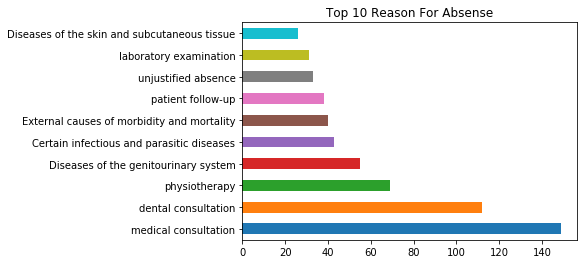

```python
vector_value =[];
vector_Reasons =['Certain infectious and parasitic diseases','Neoplasms','Diseases of the blood and blood-forming organs and certain disorders involving the immune mechanism','Endocrine, nutritional and metabolic diseases','Mental and behavioural disorders','Diseases of the nervous system','Diseases of the eye and adnexa','Diseases of the ear and mastoid process','Diseases of the circulatory system','Diseases of the respiratory system','Diseases of the digestive system','Diseases of the skin and subcutaneous tissue','Diseases of the musculoskeletal system and connective tissue','Diseases of the genitourinary system','Pregnancy, childbirth and the puerperium','Certain conditions originating in the perinatal period','Congenital malformations, deformations and chromosomal abnormalities','Symptoms, signs and abnormal clinical and laboratory findings, not elsewhere classified','Injury, poisoning and certain other consequences of external causes','External causes of morbidity and mortality','NON_SERVE','Factors influencing health status and contact with health services','patient follow-up','medical consultation','blood donation','laboratory examination','unjustified absence','physiotherapy','dental consultation'];
for index,row in input_data2.iterrows() :
    for i in range(0,29) :
        if row['Reason for absence'] == i :
            vector_value.append(vector_Reasons[i]);
            break;

input_data2['Reason for absence']=vector_value

different_reason=input_data2['Reason for absence'].value_counts()
different_reason.sort_values();
different_reason = different_reason[:10];
plt.title("Top 10 Reason For Absense");
different_reason.plot(kind='barh');
```

the most ordinary reasons for absence are commons consultation like dental consultation and medical consultation.

### univariate analysis

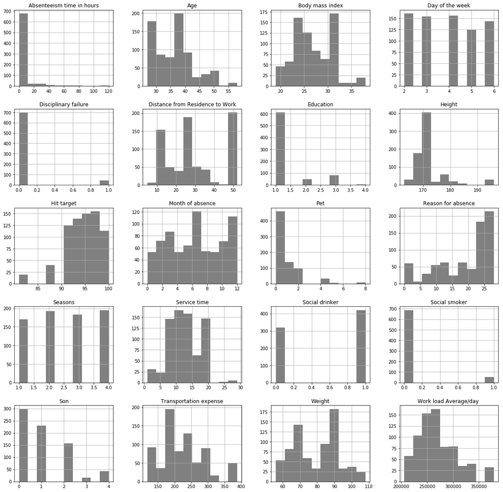

```python
hist = input_data.drop("ID",axis=1).hist(figsize=(20,20),facecolor='grey')
```

### Correlation Matrix

Here we can see the Heatmap Correlation Plot, means an heatmap that represent the value of correlation measured for each couple of feature of our dataset. Obviously, the upper-right part is equally to the lower-left one, splitted by the "1" diagonal that is the correlation of each feature with itself.

##### Correlation is a statistical term which in common usage refers to how close two variables are to having a linear relationship with each other. For example, two variables which are linearly dependent (say, x and y which depend on each other as x = 2y) will have a higher correlation than two variables which are non-linearly dependent (say, u and v which depend on each other as u = v2).

The values of the correlation coefficient can range from -1 to +1. The closer it is to +1 or -1, the more closely are the two variables are related. The positive sign signifies the direction of the correlation i.e. if one of the variables increases, the other variable is also supposed to increase, otherwise if the sign is negative, the trend is opposite.

Features with high correlation are more linearly dependent and hence have almost the same effect on the dependent variable. So, when two features have high correlation, eventually we can drop one of the two features. Meanwhile, looking at the class choosen for classification, the correlated features will be the ones more usefull for our estimator, so it is a way to display the importance of a determinated predictor knowing the prediction goal.

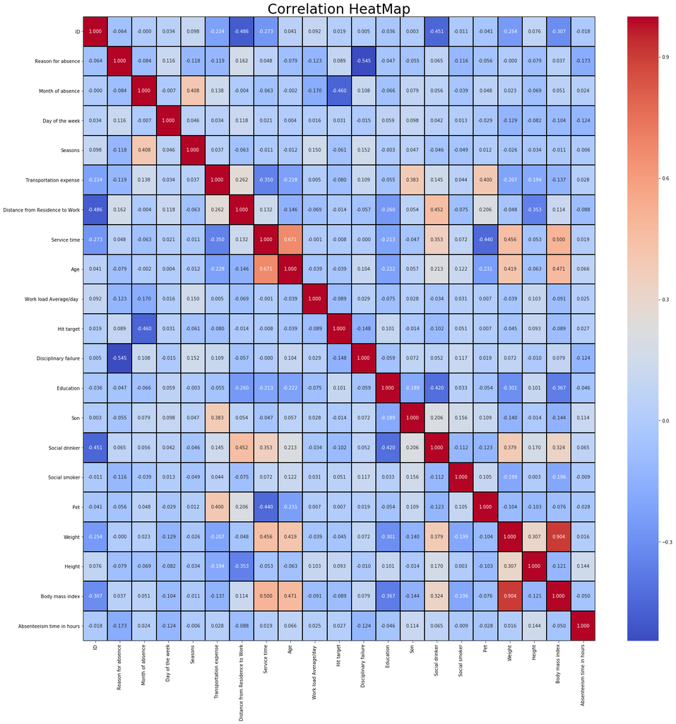

```python
fig, ax = plt.subplots(figsize=(25,25))
sns.heatmap(input_data.corr(), ax=ax, cmap='coolwarm', linewidths=1, linecolor='black', annot=True, fmt=".3f")
ax.set_title('Correlation HeatMap',fontsize=30)
```

$$ Body mass index = (weight)/(height * (costant)) $$

then for the classification we can pick to remove height and weight without loosing too accuracy for the model.

```python
input_data['Absenteeism time in hours categorical'] = target_absenteeism;
```

# 2. Dimensionality Reduction

## PCA

```python
# Normalize the numerical features
from sklearn import preprocessing

scaler = preprocessing.StandardScaler()
scaled_df = scaler.fit_transform(input_data.drop(['ID','Absenteeism time in hours','Absenteeism time in hours categorical'], axis=1, inplace=False))
scaled_df = pd.DataFrame(scaled_df, columns=['Reason for absence', 'Month of absence', 'Day of the week','Seasons','Transportation expense','istance from Residence to Work','Service time','Age','Work load Average/day','Hit target','Disciplinary failure','Education','Son','Social drinker','Social smoker','Pet','Weight','Height','Body mass index']);
```

```python
scaled_df.head()
```

|  | Reason for absence | Month of absence | Day of the week | Seasons | Transportation expense | istance from Residence to Work | Service time | Age | Work load Average/day | Hit target | Disciplinary failure | Education | Son | Social drinker | Social smoker | Pet | Weight | Height | Body mass index |
| --- | --- | --- | --- | --- | --- | --- | --- | --- | --- | --- | --- | --- | --- | --- | --- | --- | --- | --- | --- |
| 0 | 0.804938 | 0.196763 | -0.643947 | -1.390175 | 1.011408 | 0.429556 | 0.101770 | -0.532868 | -0.818212 | 0.638686 | -0.239046 | -0.433857 | 0.893723 | 0.872872 | -0.280566 | 0.19285 | 0.851673 | -0.019046 | 0.775932 |
| 1 | -2.280124 | 0.196763 | -0.643947 | -1.390175 | -1.544379 | -1.121694 | 1.242825 | 2.092860 | -0.818212 | 0.638686 | 4.183300 | -0.433857 | -0.017234 | 0.872872 | -0.280566 | -0.56624 | 1.473056 | 0.975828 | 1.009438 |
| 2 | 0.448970 | 0.196763 | 0.059924 | -1.390175 | -0.632665 | 1.441240 | 1.242825 | 0.239405 | -0.818212 | 0.638686 | -0.239046 | -0.433857 | -0.928191 | 0.872872 | -0.280566 | -0.56624 | 0.774000 | -0.350671 | 1.009438 |
| 3 | -1.449530 | 0.196763 | 0.763796 | -1.390175 | 0.861947 | -1.661258 | 0.329981 | 0.393859 | -0.818212 | 0.638686 | -0.239046 | -0.433857 | 0.893723 | 0.872872 | 3.564226 | -0.56624 | -0.857131 | -0.682295 | -0.625100 |
| 4 | 0.448970 | 0.196763 | 0.763796 | -1.390175 | 1.011408 | 0.429556 | 0.101770 | -0.532868 | -0.818212 | 0.638686 | -0.239046 | -0.433857 | 0.893723 | 0.872872 | -0.280566 | 0.19285 | 0.851673 | -0.019046 | 0.775932 |

```python
from sklearn.decomposition import PCA
# calculate the principal components
pca = PCA()
df_pca = pca.fit_transform(scaled_df)

tot = sum(pca.explained_variance_)
var_exp = [(i / tot)*100 for i in sorted(pca.explained_variance_, reverse=True)]
cum_var_exp = np.cumsum(var_exp)

trace1 = dict(
    type='bar',
    x=['PC %s' %(i+1) for i in range(20)],
    y=var_exp,
    name='Individual'
)

trace2 = dict(
    type='scatter',
    x=['PC %s' %(i+1) for i in range(20)],
    y=cum_var_exp,
    name='Cumulative'
)

data = [trace1, trace2]

layout=dict(
    title='Explained variance by different principal components',
    yaxis=dict(
        title='Explained variance in percent'
    ),
    annotations=list([
        dict(
            x=1.16,
            y=1.05,
            xref='paper',
            yref='paper',
            text='Explained Variance',
            showarrow=False,
        )
    ])
)

fig = dict(data=data, layout=layout)
iplot(fig, filename='selecting-principal-components')
```

[interactive chart not shown]

```python
n_components = 13
df_reduced = np.dot(scaled_df.values, pca.components_[:n_components,:].T)
df_reduced = pd.DataFrame(df_reduced, columns=["PC#%d" % (x + 1) for x in range(n_components)])
```

```python
df_reduced.head()
```

|  | PC#1 | PC#2 | PC#3 | PC#4 | PC#5 | PC#6 | PC#7 | PC#8 | PC#9 | PC#10 | PC#11 | PC#12 | PC#13 |
| --- | --- | --- | --- | --- | --- | --- | --- | --- | --- | --- | --- | --- | --- |
| 0 | 0.802353 | 0.939341 | -1.553804 | 0.199616 | 1.206250 | 0.259106 | -1.319147 | 0.095561 | 0.115017 | -0.230216 | -0.533807 | 0.205424 | -0.683514 |
| 1 | 3.372205 | -0.602230 | 3.342654 | 1.904904 | 0.985594 | 1.510362 | -0.698592 | 2.309549 | 0.544707 | -0.127685 | -0.332817 | -1.262448 | 0.419480 |
| 2 | 2.209115 | -0.207637 | -1.735153 | -0.202820 | -0.127748 | 0.836275 | -0.137063 | 0.915112 | 0.585357 | -0.138740 | 0.701630 | -0.072401 | 0.120813 |
| 3 | -0.580754 | 0.270916 | 0.717444 | 3.115519 | -1.487242 | 0.469020 | -2.121177 | -0.366209 | 0.480303 | 0.464699 | 0.477129 | -0.371745 | -0.389895 |
| 4 | 0.731096 | 1.058124 | -1.561927 | 0.400356 | 0.731198 | -0.039152 | -1.077291 | 0.758019 | -0.308531 | 0.653825 | -0.549172 | -0.032344 | -0.480730 |

# 3. Binary Classification

```python
print (__doc__)

from mpl_toolkits.mplot3d import Axes3D

from PIL import Image
from sklearn import preprocessing
from sklearn.model_selection import train_test_split
from sklearn.naive_bayes import GaussianNB

from sklearn.decomposition import PCA
import numpy as np
import matplotlib.pyplot as plt
import matplotlib.colors as colours
import matplotlib.image as mpimg
import glob
import os
from random import randrange
from sys import getsizeof

import pandas as pd
import numpy as np
import matplotlib.pyplot as plt
from mpl_toolkits.mplot3d import Axes3D
from sklearn import datasets, svm
from sklearn.ensemble import RandomForestClassifier
from sklearn.model_selection import train_test_split
from sklearn.decomposition import PCA
from sklearn.metrics import accuracy_score, roc_auc_score, log_loss
from matplotlib.colors import Normalize
from sklearn.preprocessing import StandardScaler
from sklearn import decomposition
from sklearn.tree import export_graphviz

from sklearn.model_selection import StratifiedShuffleSplit
from sklearn.model_selection import GridSearchCV
import random
import seaborn as sns
import csv
import time

from sklearn.naive_bayes import GaussianNB
from sklearn.svm import SVC
from sklearn.datasets import load_digits
from sklearn.model_selection import learning_curve
from sklearn.model_selection import ShuffleSplit
from sklearn import metrics

from sklearn.linear_model import LogisticRegression, LinearRegression
from sklearn import metrics

from sklearn.neighbors import KNeighborsClassifier

import matplotlib.pyplot as plt
import numpy as np
from sklearn import datasets, linear_model
import webbrowser

from sklearn.metrics import mean_squared_error, r2_score
from sklearn.feature_selection import SelectFromModel

import numpy as np
import matplotlib.pyplot as plt

from sklearn import svm, datasets
from sklearn.model_selection import train_test_split
from sklearn.metrics import confusion_matrix
from sklearn.utils.multiclass import unique_labels

import numpy as np
import matplotlib.pyplot as plt
from itertools import cycle

from sklearn import svm, datasets
from sklearn.metrics import roc_curve, auc
from sklearn.model_selection import train_test_split
from sklearn.preprocessing import label_binarize
from sklearn.multiclass import OneVsRestClassifier
from scipy import interp
from sklearn.ensemble import RandomForestClassifier
```

```
Automatically created module for IPython interactive environment
```

Constraint definition

```python
Seed1= 42
Seed2= 2
TestSize=.2

rf_params = dict(
    n_estimators=[500,1000],
    max_features=['auto'],
    criterion= ['gini', 'entropy'],)

weight_options = ['uniform', 'distance']
knn_params = dict(n_neighbors=list(range(1, 20)), weights=['uniform', 'distance'])

lr_params ={
     'penalty' : ['l1', 'l2'],
    'C' : np.logspace(-4, 4, 10)
}

C_range = [10**(-1),10**(0),10**(1)]#,10**(2),10**(3),
gamma_range = [10**(-1),10**(0),10**(1)]
rbf_svm_params = dict(gamma=gamma_range, C=C_range)
linear_svm_params = dict(C=C_range)
```

#### Graph's function

In this section I will provide all the function's declarations, used for classification procedure.

1. plot_learning_curve function : given a set of parameters, such as estimator to be represented or train sizes for learning phases, it represent the evolution of learning stage in a two curves-based graph.
2. cross_validation function : function that made the GridSearch for the classifier (and with the setup parameters) and return the best estimator based on the Accuracy scores.
3. score_model function : helpful function that plot different statistics about the estimator such as time spent for both training and test and Accuracy and LogLoss score.
4. plot_confusion_matrix function : allow to compute and display the confusion matrix for a given estimator and a given dataset.

```python
def plot_learning_curve(estimator, title, X, y, ylim=None, cv=None,
                        n_jobs=None, train_sizes=np.linspace(.01, 1.0, 50)):

    plt.figure(figsize=(15,7))
    plt.title(title)
    if ylim is not None:
        plt.ylim(*ylim)
    plt.xlabel("Training examples")
    plt.ylabel("Score")
    train_sizes, train_scores, test_scores = learning_curve(
        estimator, X, y, cv=cv, n_jobs=n_jobs, train_sizes=train_sizes)
    train_scores_mean = np.mean(train_scores, axis=1)
    train_scores_std = np.std(train_scores, axis=1)
    test_scores_mean = np.mean(test_scores, axis=1)
    test_scores_std = np.std(test_scores, axis=1)
    plt.grid()

    plt.fill_between(train_sizes, train_scores_mean - train_scores_std,
                     train_scores_mean + train_scores_std, alpha=0.1,
                     color="r")
    plt.fill_between(train_sizes, test_scores_mean - test_scores_std,
                     test_scores_mean + test_scores_std, alpha=0.1, color="g")
    plt.plot(train_sizes, train_scores_mean, 'o-', color="r",
             label="Training score")
    plt.plot(train_sizes, test_scores_mean, 'o-', color="g",
             label="Cross-validation score")

    plt.legend(loc="best")
    return plt



def cross_validation(clf, clf_params,X,y):
    start = time.time()
    best_clf = GridSearchCV(estimator=clf,param_grid=clf_params, cv=5,scoring='accuracy', return_train_score=True)
    best_clf.fit(X,y)
    end = time.time()
    print("Accuracy for result of cross validation:",best_clf.best_score_)
    print("Cross validation requires:",end-start,"sec")
    return best_clf.best_estimator_




def score_model(clf,X,y,name):
    X_train, X_test, y_train, y_test = train_test_split(X,y,test_size = TestSize,random_state=Seed1)
    start_tr = time.time()
    clf.fit(X_train,y_train)
    training_time=time.time()-start_tr
    start_te = time.time()
    predictions = clf.predict_proba(X)
    lloss=metrics.log_loss(y_true=y,y_pred=predictions,labels=[0,1])
    accuracy=clf.score(X_test,y_test)
    test_time = time.time()-start_te
    score_res = []
    score_res.append(("Name",name))
    score_res.append(("Accuracy",accuracy))
    score_res.append(("Log Loss",lloss))
    score_res.append(("Training Time",training_time))
    score_res.append(("Test Time",test_time))
    print("Scores:")
    for name,result in score_res:
        print(name,"=",result)
    return score_res



def plot_confusion_matrix(y_true, y_pred, classes,
                          normalize=False,
                          title=None,
                          cmap=plt.cm.Blues):
    """
    This function prints and plots the confusion matrix.
    Normalization can be applied by setting `normalize=True`.
    """
    if not title:
        if normalize:
            title = 'Normalized confusion matrix'
        else:
            title = 'Confusion matrix, without normalization'

    # Compute confusion matrix
    cm = metrics.confusion_matrix(y_true, y_pred)
    # Only use the labels that appear in the data
   # classes = classes[unique_labels(y_true, y_pred)]
    if normalize:
        cm = cm.astype('float') / cm.sum(axis=1)[:, np.newaxis]
        print("Normalized confusion matrix")
    else:
        print('Confusion matrix, without normalization')

    print(cm)

    fig, ax = plt.subplots()
    im = ax.imshow(cm, interpolation='nearest', cmap=cmap)
    ax.figure.colorbar(im, ax=ax)
    # We want to show all ticks...
    ax.set(xticks=np.arange(cm.shape[1]),
           yticks=np.arange(cm.shape[0]),
           # ... and label them with the respective list entries
           xticklabels=classes, yticklabels=classes,
           title=title,
           ylabel='True label',
           xlabel='Predicted label')

    # Rotate the tick labels and set their alignment.
    plt.setp(ax.get_xticklabels(), rotation=45, ha="right",
             rotation_mode="anchor")

    # Loop over data dimensions and create text annotations.
    fmt = '.2f' if normalize else 'd'
    thresh = cm.max() / 2.
    for i in range(cm.shape[0]):
        for j in range(cm.shape[1]):
            ax.text(j, i, format(cm[i, j], fmt),
                    ha="center", va="center",
                    color="white" if cm[i, j] > thresh else "black")
    fig.tight_layout()
    return ax



def normalize(X):
    npX = np.asarray(X)
    npX = preprocessing.StandardScaler(copy=True,with_mean=True,with_std=True).fit_transform(npX) #Normalization
    return pandas.DataFrame(npX)
```

```python
Scores = []
Classifiers=[]
```

```python
input_data =input_data.drop(["ID"],axis=1)
input_data =input_data.drop("Absenteeism time in hours",axis=1)
```

```python
y = input_data["Absenteeism time in hours categorical"]
print(y.shape, "diff values:", len(y.unique()))
X = input_data.drop("Absenteeism time in hours categorical",axis=1)
print(X.shape)
```

```
(740,) diff values: 2
(740, 19)
```

```python
X_train, X_test, y_train, y_test = train_test_split(X,y,test_size = 0.30,random_state=Seed1,shuffle=True)
print(X_train.shape, X_test.shape, y_train.shape, y_test.shape)
print( np.unique(y_train), np.unique(y_test))
feature_list = list(X.columns)
```

```
(518, 19) (222, 19) (518,) (222,)
[0 1] [0 1]
```

## Logistic Regression

```python
#FOR BINARY CLASSIFICATION
lr = LogisticRegression(solver='liblinear')
lr.fit(X_train,y_train)
predict_lr =lr.predict(X_test)
best_lr = cross_validation(lr,clf_params=lr_params,X=X_train,y=y_train)
Classifiers.append(best_lr)
Scores.append(score_model(best_lr,X_test,y_test,"LogisticRegression"))
```

```
Accuracy for result of cross validation: 0.7702702702702703
Cross validation requires: 0.41791439056396484 sec
Scores:
Name = LogisticRegression
Accuracy = 0.8
Log Loss = 0.4340982108718444
Training Time = 0.0009944438934326172
Test Time = 0.001997232437133789
```

```python
y_pred_lr = best_lr.predict_proba(X_test)[:, 1]
fpr_lr, tpr_lr, _ = roc_curve(y_test, y_pred_lr)
lr_auc = roc_auc_score(y_test, y_pred_lr)
```

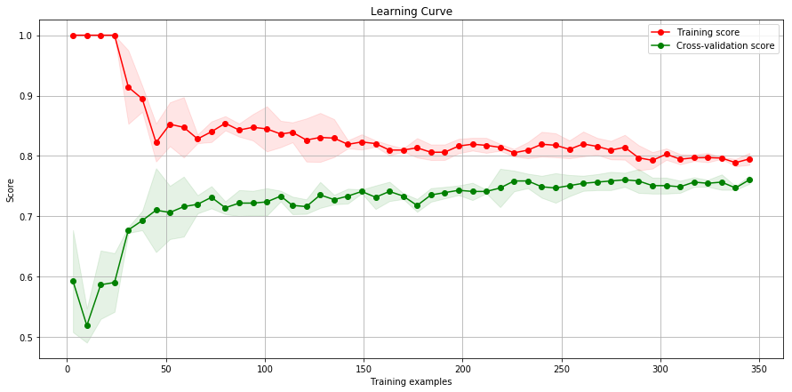

```python
plot_learning_curve(best_lr, "Learning Curve", X_train, y_train)
plt.show()
```

## Gaussian Naive Bayes Classifier

```
Scores:
Name = GaussianNB
Accuracy = 0.6888888888888889
Log Loss = 0.5627978933522746
Training Time = 0.002025604248046875
Test Time = 0.0029687881469726562
```

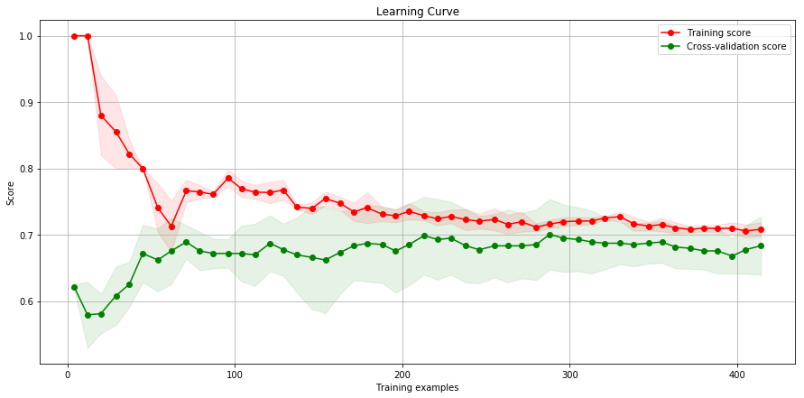

```python
gnb = GaussianNB()
predict_gnb=gnb.fit(X_train,y_train).predict(X_test)
best_gnb=gnb
Classifiers.append(best_gnb)
#NO CROSS VALIDATION FOR GAUSSIAN NB
Scores.append(score_model(best_gnb,X_test,y_test,"GaussianNB"))
plot_learning_curve(best_gnb, "Learning Curve", X_train, y_train, cv=5)
plt.show()
```

```python
y_pred_gnb = best_gnb.predict_proba(X_test)[:, 1]
fpr_gnb, tpr_gnb, _ = roc_curve(y_test, y_pred_gnb)
gnb_auc = roc_auc_score(y_test, y_pred_gnb)
```

## RandomForestClassifier

```
Accuracy for result of cross validation: 0.7992277992277992
Cross validation requires: 12.765178680419922 sec
time required: 0.40691280364990234 sec
N of features: 19
81.08 % accuracy on TEST SET, for 2 different classes
Scores:
Name = RandomForestClassifier
Accuracy = 0.8040540540540541
Log Loss = 0.17105969531574494
Training Time = 0.42685675621032715
Test Time = 0.08677053451538086
```

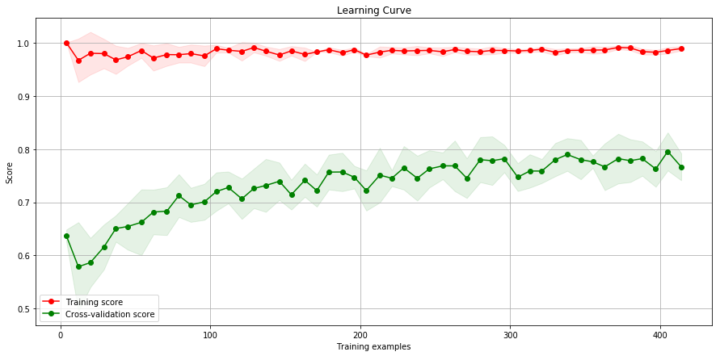

```python
rf = RandomForestClassifier()
clf = cross_validation(rf,rf_params,X_train,y_train)
start = time.time()
clf.fit(X_train, y_train)
end = time.time()
print('time required:',end-start,'sec', "\nN of features:",clf.n_features_)
print(round(clf.score(X_test, y_test),4)*100,"% accuracy on TEST SET, for 2 different classes")
Scores.append(score_model(X=X,y=y,clf=clf,name="RandomForestClassifier"))
Classifiers.append(clf)



predict_rfc=clf.fit(X_train,y_train).predict(X_test)
y_pred_rfc = clf.predict_proba(X_test)[:, 1]
fpr_rfc, tpr_rfc, _ = roc_curve(y_test, y_pred_rfc)
rfc_auc = roc_auc_score(y_test, y_pred_rfc)


plot_learning_curve(rf, "Learning Curve", X_train, y_train, cv=5)
plt.show()
```

#### Feature Importance

feature importance is a method provided by Random Forest to describe how features affects the classification in the Decision trees ensemble. So it is a first indicator of how much feature are relevant in classification and how much are quite useless. That's becouse evaluate ensemble methods is so difficult: for this reason, it is provided an overall summary of the importance of each predictor (using the cumulative decrement of Gini Index).

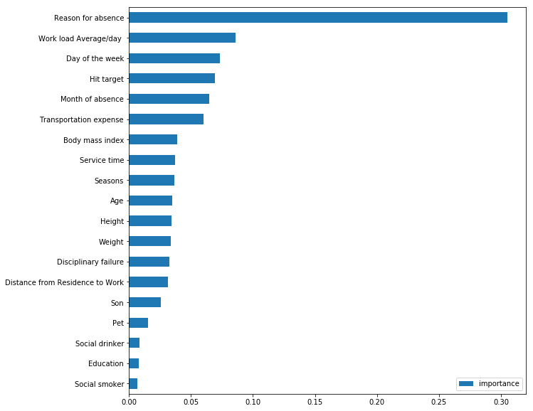

|  | importance |
| --- | --- |
| count | 19.000000 |
| mean | 0.052632 |
| std | 0.065181 |
| min | 0.006569 |
| 25% | 0.028395 |
| 50% | 0.034601 |
| 75% | 0.062384 |
| max | 0.304907 |

```python
feature_importances = pd.DataFrame(clf.feature_importances_,index = X_train.columns,columns=['importance']).sort_values('importance',ascending=True)
feature_importances.plot.barh(rot=0, figsize=(10,10), align='center')
plt.show()
feature_importances.describe()
```

```
 Name = LogisticRegression
 Accuracy = 0.8
 Log Loss = 0.4340982108718444
 Training Time = 0.0009944438934326172
 Test Time = 0.001997232437133789

 Name = GaussianNB
 Accuracy = 0.6888888888888889
 Log Loss = 0.5627978933522746
 Training Time = 0.002025604248046875
 Test Time = 0.0029687881469726562

 Name = RandomForestClassifier
 Accuracy = 0.8040540540540541
 Log Loss = 0.17105969531574494
 Training Time = 0.42685675621032715
 Test Time = 0.08677053451538086
```

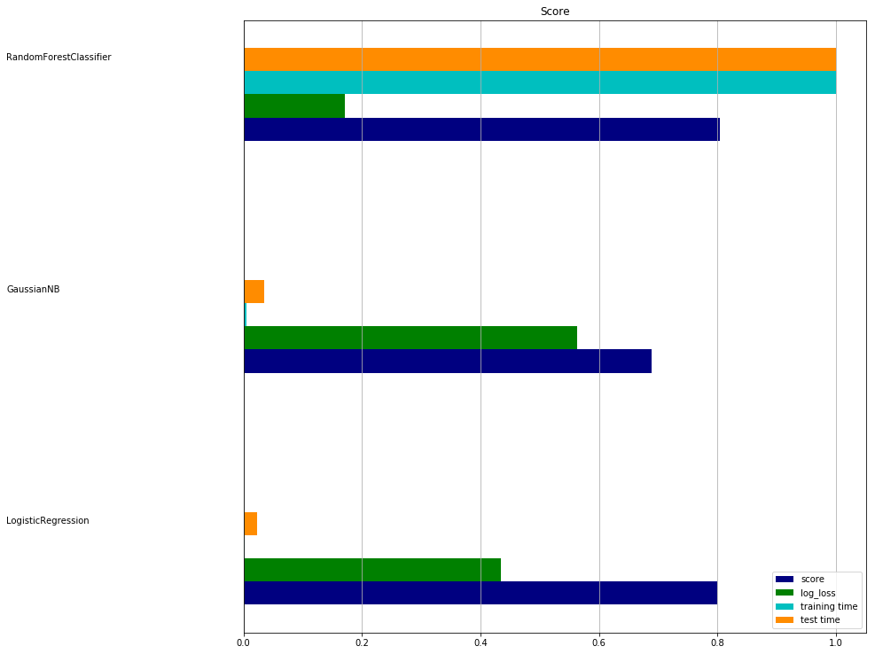

```
Total time spent in classification: 2.064306732523512
Best accuracy: 0.8040540540540541
Best L.Loss: 0.17105969531574494
```

```python
for scores in Scores:
    print(" ")
    for name,result in scores:
        print("",name,"=",result)

scores=[]
for n in range(len(Scores)):
    scores.append(list(zip(*Scores[n]))[1])


# make some plots

indices = np.arange(len(scores))
clf_names = [x[0] for x in scores]
score = [x[1] for x in scores]
log_loss = [x[2] for x in scores]
training_time = [x[3] for x in scores]
test_time = [x[4] for x in scores]
training_time = np.array(training_time) / np.max(training_time)
test_time = np.array(test_time) / np.max(test_time)

plt.figure(figsize=(15, 8))
plt.title("Score")
plt.barh(indices, score, .1, label="score", color='navy')
plt.barh(indices + .1, log_loss, .1, label="log_loss",
         color='g')
plt.barh(indices + .2, training_time, .1, label="training time",
         color='c')
plt.barh(indices + .3, test_time, .1, label="test time", color='darkorange')
plt.yticks(())
plt.grid()
plt.legend(loc='best')
plt.subplots_adjust(left=.25)
plt.subplots_adjust(top=1.25)
plt.subplots_adjust(bottom=.05)

for i, c in zip(indices, clf_names):
    plt.text(-.4, i+.3, c)

plt.show()



print("Total time spent in classification:", np.sum(np.asarray(training_time))+np.sum(np.asarray(test_time)))
print("Best accuracy:",np.max(score))
print("Best L.Loss:",np.min(log_loss))
```

```
Confusion matrix, without normalization
[[123  22]
 [ 55  22]]
Confusion matrix, without normalization
[[120  25]
 [ 44  33]]
Confusion matrix, without normalization
[[119  26]
 [ 17  60]]
```

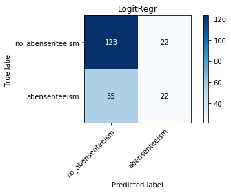

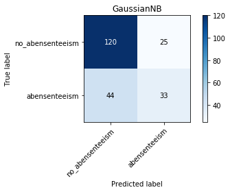

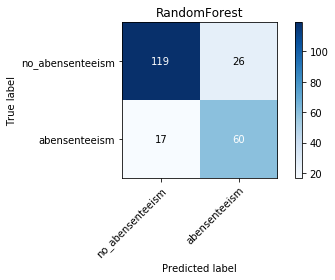

```python
predictions = [predict_lr, predict_gnb, predict_rfc]
names_prdt = ["LogitRegr","GaussianNB","RandomForest"]
for i,prdt in enumerate(predictions):
    plot_confusion_matrix(y_test, prdt, classes=["no_abensenteeism","abensenteeism"],
                      title=names_prdt[i])
```

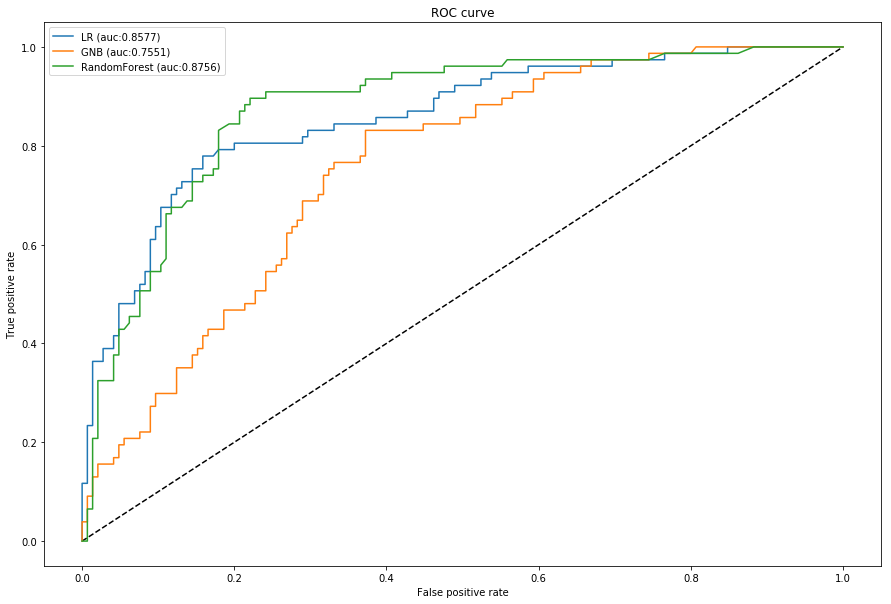

```python
# y_pred_grd_lm = grd_lm.predict_proba(
#     grd_enc.transform(grd.apply(X_test)[:, :, 0]))[:, 1]
# fpr_grd_lm, tpr_grd_lm, _ = roc_curve(y_test, y_pred_grd_lm)

# # The gradient boosted model by itself
# y_pred_grd = grd.predict_proba(X_test)[:, 1]
# fpr_grd, tpr_grd, _ = roc_curve(y_test, y_pred_grd)

#svm_auc = round(svm_auc,4)
lr_auc = round(lr_auc,4)
gnb_auc = round(gnb_auc,4)
rfc_auc = round(rfc_auc,4)

plt.figure(figsize=(15,10))
plt.plot([0, 1], [0, 1], 'k--')
plt.plot(fpr_lr, tpr_lr, label='LR (auc:'+str(lr_auc)+')')
plt.plot(fpr_gnb, tpr_gnb, label='GNB (auc:'+str(gnb_auc)+')')
#plt.plot(fpr_svm, tpr_svm, label='SVM (auc:'+str(svm_auc)+')')
plt.plot(fpr_rfc, tpr_rfc, label='RandomForest (auc:'+str(rfc_auc)+')')
plt.xlabel('False positive rate')
plt.ylabel('True positive rate')
plt.title('ROC curve')
plt.legend(loc='best')
plt.show()
```